# ncov-recombinant v0.4.2 - v0.5.0

Test Summary Package

*This report was automatically generated on October 3, 2022.*

## Authors

**Katherine Eaton** | National Microbiology Laboratory, PHAC | katherine.eaton@phac-aspc.gc.ca

## 1. Summary

The ncov-recombinant update from `v0.4.2` to `v0.5.0` has two major changes. The first is increased flexibility in creating and defining `sc2rf` modes, which allows `sc2rf` to run with different parameter sets for breakpoint detection. The second change is a `Nextclade` upgrade to the [sars-cov-2 2022-09-27 dataset](https://github.com/nextstrain/nextclade_data/releases/tag/2022-09-28--16-01-10--UTC), along with validation of all designated recombinants in this dataset (XA to XBC).

Between `v0.4.2` and `v0.5.0`, **47.5%** of sequences in the `controls-gisaid` dataset had different detection results. **16.2%** of sequences were newly classified (`NA` → `X*`) and represent lineages not present in the `v0.4.2` model. **31.3%** of sequences had lineage assignment changes as a result of the `Nextclade` dataset upgrade and manual curation of previously published breakpoints. **0%** of positive controls were dropped between (`X*` → `NA`), indicating no observed loss in sensitivity.

`ncov-recombinant` `v0.5.0` is a *strongly* recommended upgrade for monitoring existing recombinants and performing routine surveillance for emerging lineages, given the high proportion of sequences (**47.5%**) with lineage assignment changes.

For a comprehensive summary of the methodological changes, please see the [release notes for v0.5.0](https://github.com/ktmeaton/ncov-recombinant/releases/tag/v0.5.0)

## 2. Purpose

Verify that the update of ncov-recombinant pipeline from version `0.4.2` to`0.5.0`:

1. Maintains specificity for recombinants trained in previous versions.
2. Increased sensitivity for newly designated recombinants.

## 3. Datasets

### Controls (`controls-gisaid`)

This dataset includes SARS-CoV-2 genomes from GISAID that reflect the known diversity of recombinant sequences to date. These include `431` positive controls (recombinants), representing lineages XA - XBC and `186` negative controls (non-recombinants) selected from the [Nextstrain Reference Phylogeny](https://nextstrain.org/ncov/gisaid/reference).

In total, `617` control sequences were used as input and a [strain list is available here](https://raw.githubusercontent.com/ktmeaton/ncov-recombinant/v0.5.0/data/controls-gisaid/strains.txt).

## 4. Procedure

The snakemake pipelines for `v0.4.2` and `v0.5.0` were run independently on the same dataset (`controls-gisaid`). Please see the Procedure section in the Supplementary for detailed command-line instructions.

## 5. Results

### Controls (`controls-gisaid`)

- **52.4%** (226/431) of lineage assignments were unchanged (Figure 1).
- **16.2%** (70/431) of sequences were newly classified as recombinants.
- **31.3%** (135/431) of sequences changed lineage assignments.
- **0.0%** (0/431) of sequences were dropped as positives (`NA`).

> **Note**: Lineage assignments in `v0.5.0` are identical to those in pango-designation and are the expected values.

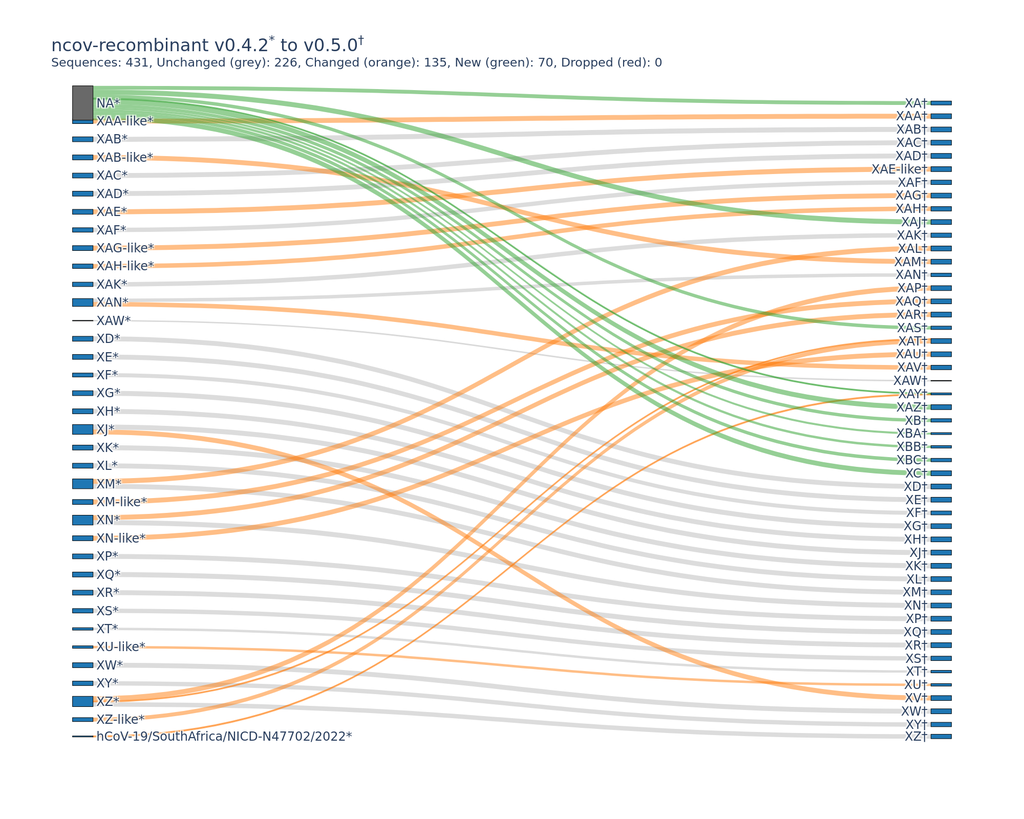

Figure 1: Comparison of lineage assignments in the `controls-gisaid` dataset between `v0.4.2` and `v0.5.0`.

#### New Detections

**New detections** (`NA` → `X*`) result from the following changes in `v0.5.0`:

1. New parameters for recombination involving clades other than Delta and Omicron: XA, XB, XC.
2. New parameters for recombination occurring within clades (ex. BA.2): XBB
3. New edge case handling: XN, XP, XAR, XAS, XAZ
4. Removed restrictions on the number of breakpoints: XAY, XBA, XBC
5. Clade definition updates to include recombination involving 22C (BA.2.12): XAJ

#### Lineage Changes

**Lineage changes** result from the following updates in `v0.5.0`:

1. Curation of published breakpoints.
   - XJ → XV
   - XAG-like → XAG
   - XAH-like → XAH
   - XAN → XAV
   - XU-like → XU
2. Nextclade dataset updates.
   - XM-like → XAQ
   - XN-like → XAU
   - XZ-like → XAT
   - XAA-like → XAA
   - XAB-like → XAM
   - hCoV-19/SouthAfrica → XAY
   - XM → XAL*
   - XN → XAR†
   - XZ → XAP‡

* **Why were sequences of XAL assigned to XM rather than XM-like in `v0.4.2` ?**

> `XAL` is almost identical to `XM`, with the same hotspot breakpoint (`17411:19954`), and the same high-confidence parental lineages (`BA.1.1*`,`BA.2*`; confidence: `0.994`,`0.996`). Before `XAL` was designated, ncov-recombinant had no way to detect that sequences of `XAL` belonged to a distinct cluster from `XM`. Furthermore, `XAL` only differs from `XM` by two mutations (`A2865G`, `G21586T`) which is insufficient evidence for ncov-recombinant to call this `XM-like` (by default, requires a minimum of three mutations). Finally, it is unclear whether XAL emerged from a unique recombination event, or is a sublineage within XM. For more information, please see pango-designation issue [XAL #757](https://github.com/cov-lineages/pango-designation/issues/757).

† **Why were sequences of XAR assigned to XN rather than XN-like in `v0.4.2` ?**

> XAR and XN are handed as special cases by ncov-recombinant, because their breakpoints lie at the extreme 5’ end of the genome (`2834:4183`) with few diagnostic alleles from a second parent (BA.1). Breakpoint and parents often cannot be detected by sc2rf and therefore before XAR was designated, ncov-recombinant could not differentiate them. For more information, please see ncov-recombinant issues [XN #137](https://github.com/ktmeaton/ncov-recombinant/issues/137), [XAR #106](https://github.com/ktmeaton/ncov-recombinant/issues/106), [#74](https://github.com/ktmeaton/ncov-recombinant/issues/74), and [#90](https://github.com/ktmeaton/ncov-recombinant/issues/90).

‡ **Why were sequences of XAP assigned to XZ rather than XZ-like in `v0.4.2` ?**

> `XAP` is almost identical to `XZ`, with the same hotspot breakpoint (`26061:26529`), and the same parental lineages (`BA.2*`,`BA.1.1*`; confidence: `0.999`,`0.544`). See the above discussion on XAL* for more information.

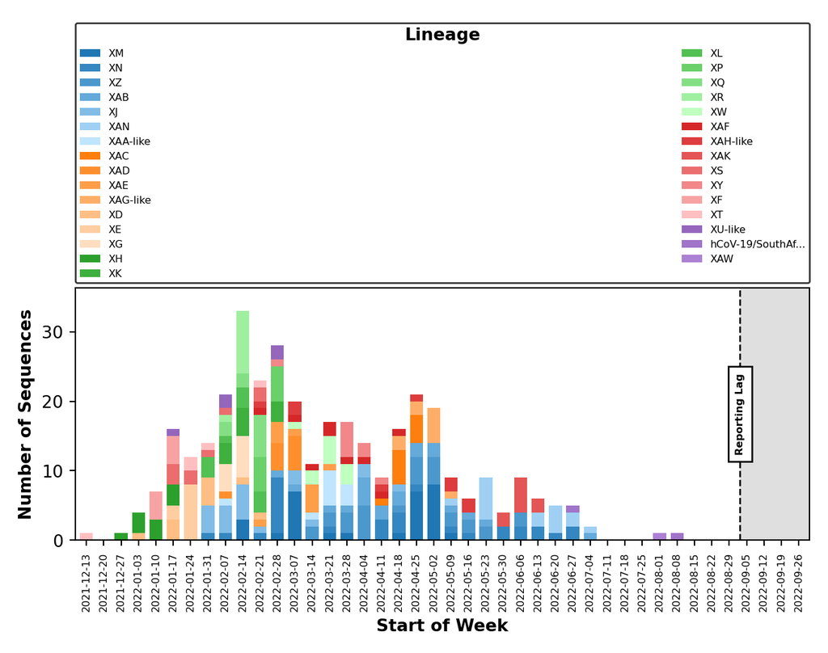

Figure 2: Historical timeline of recombinants in the `controls-gisaid` dataset in `v0.4.2`.

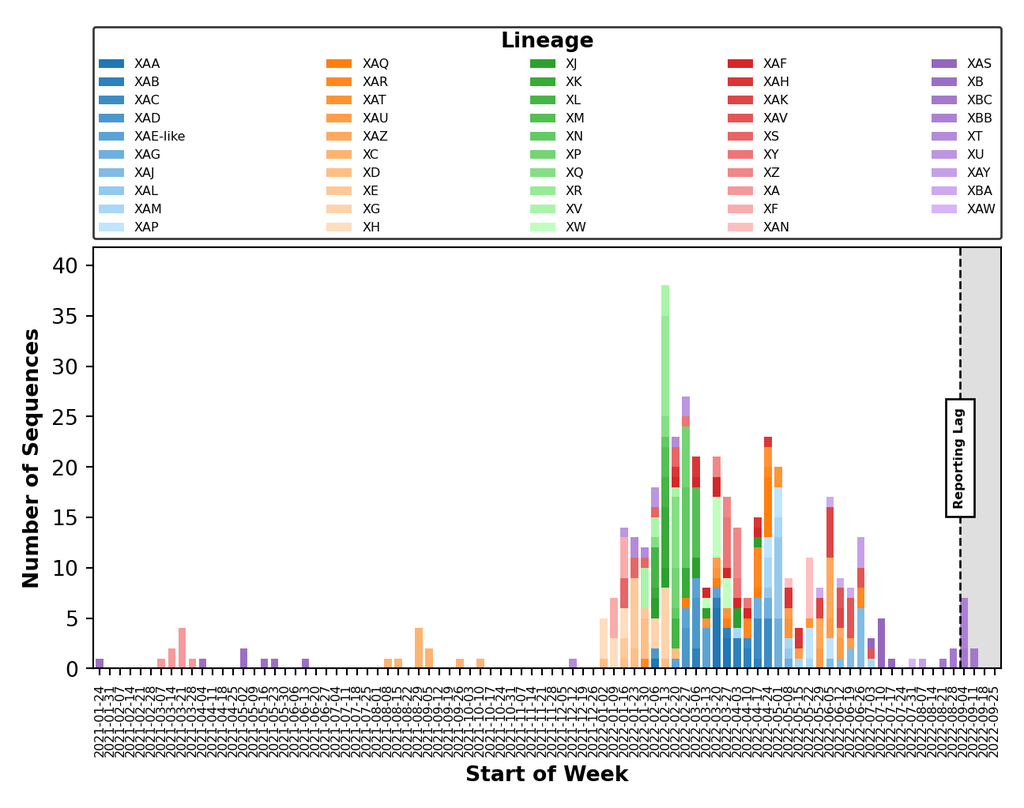

Figure 3: Historical timeline of recombinants in the `controls-gisaid` dataset in `v0.5.0`.

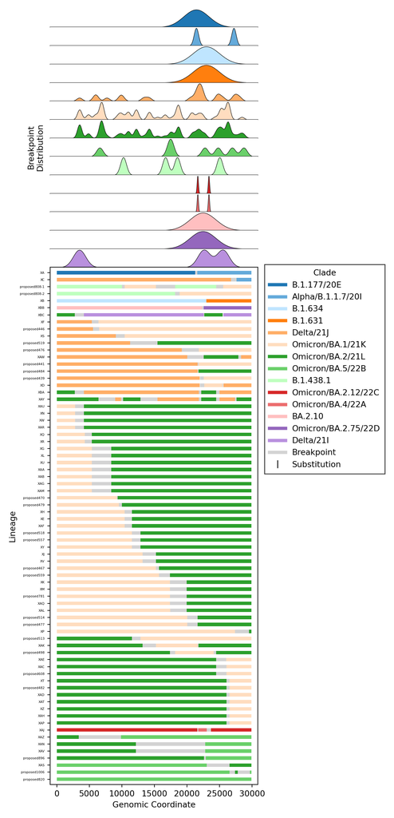

Figure 4: Breakpoint distributions by clade of the `controls-gisaid` dataset in `v0.5.0`.

## Supplementary

> **Note**: Download the GISDAID sequences and metadata in the [strains list](https://raw.githubusercontent.com/ktmeaton/ncov-recombinant/v0.5.0/data/controls-gisaid/strains.txt).

### Procedure

#### Version 0.4.2 | 37f40480

> **Note**: A commit hash (`37f40480`) is used instead of the tag (`v0.4.2`), for an important bugfix that was introduced between `v0.4.2` and `v0.4.3`.
1. Download the pipeline.

   ```bash
   git clone --recursive https://github.com/ktmeaton/ncov-recombinant.git 0.4.2
   cd 0.4.2
   git checkout 37f40480
   ```

2. Version control submodules.

   ```bash
   cd sc2rf
   git checkout 2852f05a
   cd ..
   ```

3. Create a version-controlled conda environment.

   ```bash
   mamba env create -f workflow/envs/environment.yaml -n ncov-recombinant-0.4.2
   ```

4. Create profile for `controls-gisaid`.

   ```bash
   scripts/create_profile.sh --data data/controls-gisaid --hpc
   ```

5. Manually change `MIN_LINEAGE_SIZE` in `scripts/linelist.py` to 5.
   - This is because this parameter was hard-coded before `v0.5.0`.
6. Run the pipeline.

   ```bash
   scripts/slurm.sh --conda-env ncov-recombinant-0.4.2 --profile my_profiles/controls-gisaid-hpc
   ```

#### Version 0.5.0 | e90f5ac1

1. Download the pipeline.

   ```bash
   git clone https://github.com/ktmeaton/ncov-recombinant.git 0.5.0
   cd 0.5.0
   git checkout v0.5.0
   ```

2. Create a version-controlled conda environment.

   ```bash
   mamba env create -f workflow/envs/environment.yaml -n ncov-recombinant-0.5.0
   ```

3. Run the pipeline.

   ```bash
   scripts/slurm.sh --conda-env ncov-recombinant-0.5.0 --profile my_profiles/controls-gisaid-hpc
   ```

### Comparison

After the pipelines are complete for each version, run the following to compare lineage assignments.

```bash
python3 0.5.0/scripts/compare_positives.py \
  --positives-1 0.4.2/results/controls-gisaid/linelists/positives.tsv \
  --positives-2 0.5.0/results/controls-gisaid/linelists/positives.tsv \
  --ver-1 "v0.4.2" \
  --ver-2 "v0.5.0" \
  --outdir compare/controls-gisaid \
  --node-order alphabetical \
  --min-link-size 1
```

#### New Lineages

```bash
csvtk cut -t -f "strain" 0.4.2/results/controls-gisaid/linelists/positives.tsv \
  | tail -n+2 \
  | csvtk grep -t -f "strain" -P - -v 0.5.0/results/controls-gisaid/linelists/positives.tsv \
  | csvtk cut -t -f "strain" \
  | tail -n+2 \
  | csvtk grep -t -f "strain" -P - 0.4.2/results/controls-gisaid/linelists/linelist.tsv \
  | csvtk pretty -t \
  | less -S
```

#### Dropped Lineages

```bash
csvtk cut -t -f "strain" 0.5.0/results/controls-gisaid/linelists/positives.tsv \
  | tail -n+2 \
  | csvtk grep -t -f "strain" -P - -v 0.4.2/results/controls-gisaid/linelists/positives.tsv \
  | csvtk cut -t -f "strain" \
  | tail -n+2 \
  | csvtk grep -t -f "strain" -P - 0.5.0/results/controls-gisaid/linelists/linelist.tsv \
  | csvtk pretty -t \
  | less -S
```